# Lab4

2026-03-19

# Link de GitHub:

https://github.com/can23384/Lab4_DM.git

```r
library(tidyverse)
library(rsample)
library(janitor)
library(lubridate)
library(rpart)
library(rpart.plot)
```

```r
tmp_env <- new.env()
load("listings.RData", envir = tmp_env)

ls(tmp_env)
```

```
## [1] "listings"
```

```r
objetos <- mget(ls(tmp_env), envir = tmp_env)

listings <- objetos %>%
  keep(~ is.data.frame(.x)) %>%
  .[[1]]
```

```r
parse_money_clean <- function(x) {
  if (is.numeric(x)) return(x)
  x %>%
    as.character() %>%
    str_replace_all("\\$", "") %>%
    str_replace_all(",", "") %>%
    str_trim() %>%
    na_if("") %>%
    as.numeric()
}

parse_percent_clean <- function(x) {
  if (is.numeric(x)) return(x)
  x %>%
    as.character() %>%
    str_replace_all("%", "") %>%
    str_trim() %>%
    na_if("") %>%
    as.numeric()
}

listings <- listings %>%
  clean_names()

if ("price" %in% names(listings)) {
  listings <- listings %>% mutate(price = parse_money_clean(price))
}

if ("host_response_rate" %in% names(listings)) {
  listings <- listings %>% mutate(host_response_rate = parse_percent_clean(host_response_rate))
}

if ("host_acceptance_rate" %in% names(listings)) {
  listings <- listings %>% mutate(host_acceptance_rate = parse_percent_clean(host_acceptance_rate))
}

cols_fecha <- c("host_since", "first_review", "last_review", "last_scraped")
cols_fecha <- cols_fecha[cols_fecha %in% names(listings)]

if (length(cols_fecha) > 0) {
  listings <- listings %>%
    mutate(across(all_of(cols_fecha), ~ suppressWarnings(ymd(.x))))
}

listings <- listings %>%
  select(where(~ !is.list(.x))) %>%
  mutate(across(where(is.character), as.factor))
```

# 1. Use los mismos conjuntos de entrenamiento y prueba que usó para los modelos de regresión lineal en la entrega anterior.

```r
set.seed(123)

split_master <- initial_split(
  listings,
  prop = 0.80,
  strata = price
)

train_data <- training(split_master)
test_data  <- testing(split_master)

dim(train_data)
```

```
## [1] 137397     80
```

```r
dim(test_data)
```

```
## [1] 34351    80
```

```r
factor_cols <- names(train_data)[sapply(train_data, is.factor)]

for (col in factor_cols) {
  if (col %in% names(test_data)) {
    test_data[[col]] <- factor(test_data[[col]], levels = levels(train_data[[col]]))
  }
}
```

```r
vars_quitar <- intersect(
  names(train_data),
  c(
    "id", "listing_url", "scrape_id", "source", "name", "description",
    "neighborhood_overview", "picture_url", "host_id", "host_url",
    "host_name", "host_location", "host_about",
    "host_thumbnail_url", "host_picture_url",
    "license", "amenities"
  )
)

train_model <- train_data %>% select(-all_of(vars_quitar))
test_model  <- test_data  %>% select(-all_of(vars_quitar))

# quitar columnas con demasiados NA, pero conservar price
prop_na <- sapply(train_model, function(x) mean(is.na(x)))
cols_muchos_na <- names(prop_na[prop_na > 0.40])
cols_muchos_na <- setdiff(cols_muchos_na, "price")

train_model <- train_model %>% select(-all_of(cols_muchos_na))
test_model  <- test_model %>% select(-all_of(cols_muchos_na))

train_model <- train_model %>% filter(!is.na(price)) %>% drop_na()
test_model  <- test_model %>% filter(!is.na(price)) %>% drop_na()

names(train_model)
```

```
##  [1] "last_scraped"
##  [2] "host_since"
##  [3] "host_response_time"
##  [4] "host_response_rate"
##  [5] "host_acceptance_rate"
##  [6] "host_is_superhost"
##  [7] "host_neighbourhood"
##  [8] "host_listings_count"
##  [9] "host_total_listings_count"
## [10] "host_verifications"
## [11] "host_has_profile_pic"
## [12] "host_identity_verified"
## [13] "neighbourhood"
## [14] "neighbourhood_cleansed"
## [15] "neighbourhood_group_cleansed"
```

[output cut: 46 more lines]

# 2. Elabore un árbol de regresión para predecir el precio de las casas por noche usando todas las variables.

```r
arbol_precio <- rpart(
  formula = price ~ .,
  data = train_model,
  method = "anova",
  control = rpart.control(
    cp = 0.001,
    minsplit = 20,
    maxdepth = 10
  )
)
```

```r
printcp(arbol_precio)
```

```
##
## Regression tree:
## rpart(formula = price ~ ., data = train_model, method = "anova",
##     control = rpart.control(cp = 0.001, minsplit = 20, maxdepth = 10))
##
## Variables actually used in tree construction:
##  [1] accommodates                   availability_365
##  [3] bathrooms_text                 calculated_host_listings_count
##  [5] first_review                   host_neighbourhood
##  [7] host_since                     host_total_listings_count
##  [9] last_review                    maximum_nights
## [11] minimum_maximum_nights         neighbourhood_cleansed
## [13] property_type                  review_scores_value
## [15] room_type
##
## Root node error: 1.422e+11/23329 = 6095359
##
## n= 23329
##
##           CP nsplit rel error  xerror     xstd
## 1  0.5139955      0   1.00000 1.00011 0.121408
## 2  0.1250327      1   0.48600 0.54212 0.074677
## 3  0.0553752      2   0.36097 0.43333 0.073086
## 4  0.0140712      4   0.25022 0.33693 0.059536
## 5  0.0135334      5   0.23615 0.33833 0.059738
## 6  0.0134214      6   0.22262 0.33310 0.059721
## 7  0.0085407      7   0.20920 0.32191 0.059707
## 8  0.0052705      8   0.20065 0.32430 0.060162
## 9  0.0029777      9   0.19538 0.32282 0.059752
## 10 0.0020294     12   0.18645 0.32574 0.058610
## 11 0.0013909     13   0.18442 0.32611 0.058611
## 12 0.0013158     16   0.18025 0.32737 0.058670
## 13 0.0012029     17   0.17893 0.32686 0.058671
## 14 0.0010000     20   0.17532 0.32371 0.058602
```

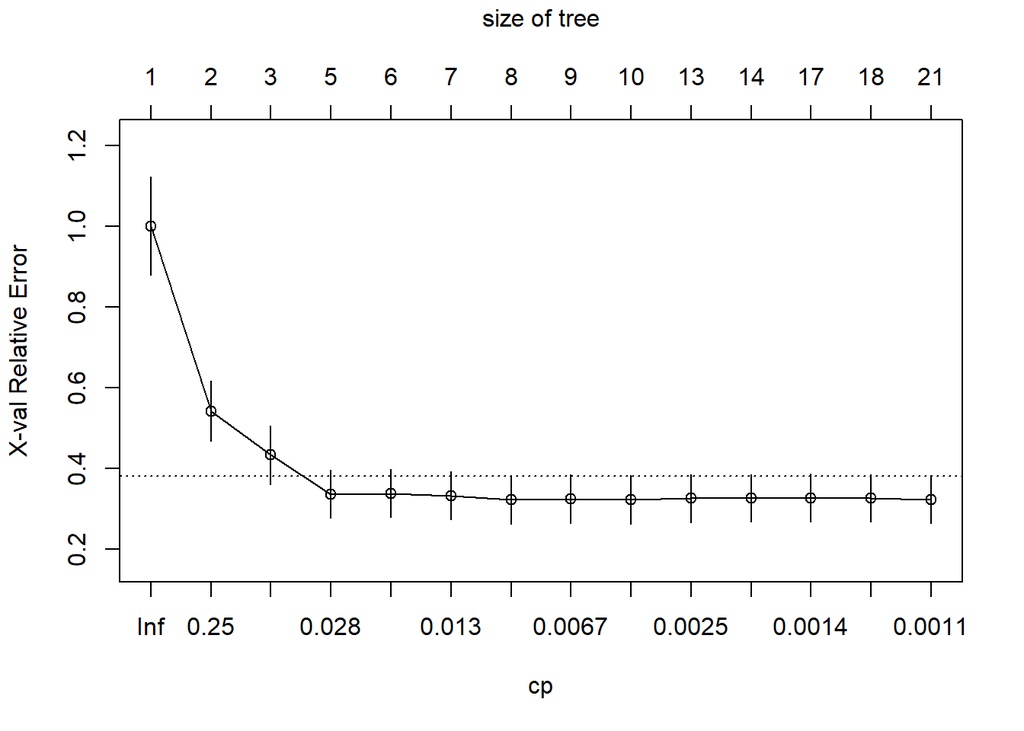

```r
plotcp(arbol_precio)
```

```r
mejor_cp <- arbol_precio$cptable[which.min(arbol_precio$cptable[, "xerror"]), "CP"]
mejor_cp
```

```
## [1] 0.008540663
```

```r
arbol_podado <- prune(arbol_precio, cp = mejor_cp)
```

[figure not shown]

```r
rpart.plot(
  arbol_podado,
  type = 3,
  extra = 101,
  fallen.leaves = TRUE,
  cex = 0.6
)
```

# 3. Úselo para predecir y analice el resultado. ¿Qué tal lo hizo?

```r
pred_train <- predict(arbol_podado, newdata = train_data)
pred_test  <- predict(arbol_podado, newdata = test_data)

head(pred_test)
```

```
##        1        2        3        4        5        6
## 340.9031 340.9031 340.9031 340.9031 340.9031 340.9031
```

```r
rmse <- function(obs, pred) sqrt(mean((obs - pred)^2, na.rm = TRUE))
mae  <- function(obs, pred) mean(abs(obs - pred), na.rm = TRUE)
r2   <- function(obs, pred) 1 - sum((obs - pred)^2, na.rm = TRUE) / sum((obs - mean(obs, na.rm = TRUE))^2, na.rm = TRUE)

resultados <- tibble(
  conjunto = c("Entrenamiento", "Prueba"),
  RMSE = c(rmse(train_data$price, pred_train), rmse(test_data$price, pred_test)),
  MAE  = c(mae(train_data$price, pred_train),  mae(test_data$price, pred_test)),
  R2   = c(r2(train_data$price, pred_train),   r2(test_data$price, pred_test))
)

resultados
```

```
## # A tibble: 2 × 4
##   conjunto       RMSE   MAE     R2
##   <chr>         <dbl> <dbl>  <dbl>
## 1 Entrenamiento 4647.  799. -0.163
## 2 Prueba        4338.  737. -0.171
```

```r
importancia <- arbol_podado$variable.importance

importancia_df <- tibble(
  variable = names(importancia),
  importancia = as.numeric(importancia)
) %>%
  arrange(desc(importancia))

importancia_df
```

```
## # A tibble: 23 × 2
##    variable                   importancia
##    <chr>                            <dbl>
##  1 host_total_listings_count 81127359310.
##  2 host_neighbourhood        63876697332.
##  3 availability_365          17779475540.
##  4 availability_eoy          17779475540.
##  5 availability_30           16411823575.
##  6 availability_60           16411823575.
##  7 availability_90           16411823575.
##  8 minimum_maximum_nights    11560844069.
##  9 maximum_minimum_nights     8407886596.
## 10 minimum_nights_avg_ntm     7356900771.
## # ℹ 13 more rows
```

# 4. Haga, al menos, 3 modelos más, cambiando el parámetro de la profundidad del árbol. ¿Cuál es el mejor modelo para predecir el precio por noche?

```r
rmse <- function(obs, pred) sqrt(mean((obs - pred)^2, na.rm = TRUE))
mae  <- function(obs, pred) mean(abs(obs - pred), na.rm = TRUE)
r2   <- function(obs, pred) {
  1 - sum((obs - pred)^2, na.rm = TRUE) /
    sum((obs - mean(obs, na.rm = TRUE))^2, na.rm = TRUE)
}

profundidades <- c(3, 5, 7, 9)

resultados_modelos <- data.frame()
modelos_arbol <- list()

for (d in profundidades) {

  modelo <- rpart(
    formula = price ~ .,
    data = train_model,
    method = "anova",
    control = rpart.control(
      cp = 0.001,
      minsplit = 20,
      maxdepth = d
    )
  )

  pred_train <- predict(modelo, newdata = train_model)
  pred_test  <- predict(modelo, newdata = test_model)

  resultados_modelos <- rbind(
    resultados_modelos,
    data.frame(
      maxdepth = d,
      RMSE_train = rmse(train_model$price, pred_train),
      MAE_train  = mae(train_model$price, pred_train),
      R2_train   = r2(train_model$price, pred_train),
      RMSE_test  = rmse(test_model$price, pred_test),
      MAE_test   = mae(test_model$price, pred_test),
      R2_test    = r2(test_model$price, pred_test)
    )
  )

  modelos_arbol[[paste0("depth_", d)]] <- modelo
}

resultados_modelos
```

```
##   maxdepth RMSE_train MAE_train  R2_train RMSE_test MAE_test   R2_test
## 1        3   1177.863  278.9906 0.7723904  1249.988 283.1650 0.6902250
## 2        5   1091.301  233.0563 0.8046157  1190.067 244.5992 0.7192127
## 3        7   1078.763  214.0840 0.8090795  1186.132 225.6859 0.7210661
## 4        9   1044.348  212.5951 0.8210667  1199.652 226.9487 0.7146714
```

```r
resultados_modelos %>%
  arrange(RMSE_test)
```

```
##   maxdepth RMSE_train MAE_train  R2_train RMSE_test MAE_test   R2_test
## 1        7   1078.763  214.0840 0.8090795  1186.132 225.6859 0.7210661
## 2        5   1091.301  233.0563 0.8046157  1190.067 244.5992 0.7192127
## 3        9   1044.348  212.5951 0.8210667  1199.652 226.9487 0.7146714
## 4        3   1177.863  278.9906 0.7723904  1249.988 283.1650 0.6902250
```

```r
mejor_fila <- resultados_modelos %>%
  arrange(RMSE_test) %>%
  slice(1)

mejor_fila
```

```
##   maxdepth RMSE_train MAE_train  R2_train RMSE_test MAE_test   R2_test
## 1        7   1078.763   214.084 0.8090795  1186.132 225.6859 0.7210661
```

[figure not shown]

```r
mejor_depth <- mejor_fila$maxdepth
mejor_modelo <- modelos_arbol[[paste0("depth_", mejor_depth)]]

rpart.plot(
  mejor_modelo,
  type = 3,
  extra = 101,
  fallen.leaves = TRUE,
  cex = 0.7
)
```

```r
importancia <- mejor_modelo$variable.importance

importancia_df <- tibble(
  variable = names(importancia),
  importancia = as.numeric(importancia)
) %>%
  arrange(desc(importancia))

importancia_df
```

```
## # A tibble: 25 × 2
##    variable                   importancia
##    <chr>                            <dbl>
##  1 host_total_listings_count 81127359310.
##  2 host_neighbourhood        63949635821.
##  3 availability_365          17779475540.
##  4 availability_eoy          17779475540.
##  5 availability_60           16816647124.
##  6 availability_90           16816647124.
##  7 availability_30           16411823575.
##  8 minimum_maximum_nights    11560844069.
##  9 maximum_minimum_nights     8407886596.
## 10 minimum_nights_avg_ntm     7356900771.
## # ℹ 15 more rows
```

Se compararon cuatro árboles de regresión variando la profundidad máxima (maxdepth = 3, 5, 7 y 9). El mejor modelo fue el de profundidad 7, ya que presentó el menor RMSE en el conjunto de prueba (1186.132), el menor MAE (225.6859) y el mayor R² (0.7211). Por lo tanto, este modelo fue el que mostró el mejor desempeño predictivo para estimar el precio por noche. Este modelo logró el menor error de predicción y el mayor poder explicativo en prueba. Sin embargo, la mejora respecto al árbol con profundidad 5 fue pequeña, por lo que no se trata de una diferencia enorme, sino de una ventaja moderada.

# 5. Compare los resultados con el modelo de regresión lineal de la hoja anterior, ¿cuál lo hizo mejor?

Al comparar el mejor árbol de regresión con los modelos de regresión lineal del laboratorio anterior, se observa que el árbol con maxdepth = 7 presentó el mejor desempeño predictivo. Entre los modelos lineales, el mejor fue el modelo reducido, con RMSE = 2442.887, MAE = 256.8089 y R² = 0.0323 en el conjunto de prueba. En cambio, el árbol obtuvo RMSE = 1186.132, MAE = 225.6859 y R² = 0.7211. Por lo tanto, el árbol de regresión predijo mejor el precio por noche, especialmente porque redujo de forma importante el RMSE.

Mejor árbol: maxdepth = 7

RMSE_test = 1186.132

MAE_test = 225.6859

R²_test = 0.7211

Mejor lineal: modelo reducido RMSE_test = 2442.887

MAE_test = 256.8089

R²_test = 0.0323

# 6. Dependiendo del análisis exploratorio elaborado cree una variable respuesta que le permita clasificar las casas en Económicas, Intermedias o Caras. Los límites de estas clases deben tener un fundamento en la distribución de los datos de precios, y estar bien explicados.

```r
listings <- listings %>%
  mutate(
    categoria_precio = case_when(
      is.na(price) ~ NA_character_,
      price <= 119 ~ "Económica",
      price > 119 & price <= 323 ~ "Intermedia",
      price > 323 ~ "Cara"
    )
  )

listings$categoria_precio <- factor(
  listings$categoria_precio,
  levels = c("Económica", "Intermedia", "Cara")
)

table(listings$categoria_precio, useNA = "ifany")
```

```
##
##  Económica Intermedia       Cara       <NA>
##      18897      38000      19349      95502
```

```r
prop.table(table(listings$categoria_precio))
```

```
##
##  Económica Intermedia       Cara
##  0.2478425  0.4983868  0.2537707
```

```r
listings %>%
  count(categoria_precio) %>%
  mutate(proporcion = n / sum(n))
```

```
##   categoria_precio     n proporcion
## 1        Económica 18897  0.1100275
## 2       Intermedia 38000  0.2212544
## 3             Cara 19349  0.1126592
## 4             <NA> 95502  0.5560589
```

Para construir una variable respuesta que permitiera clasificar las propiedades en Económicas, Intermedias y Caras, se utilizaron puntos de corte basados en la distribución empírica del precio por noche. Dado que en el análisis exploratorio se observó que la variable price presenta una distribución fuertemente asimétrica hacia la derecha y con presencia de valores extremos, no resultaba adecuado definir las categorías usando intervalos de igual amplitud o la media. En su lugar, se emplearon los cuartiles de la distribución, ya que son medidas más robustas ante la existencia de outliers y reflejan mejor la concentración real de los datos.

Con este criterio, se definieron como Económicas las propiedades con price <= 119, como Intermedias aquellas con 119 < price <= 323, y como Caras las propiedades con price > 323. Estos puntos de corte corresponden al primer cuartil y al tercer cuartil de la distribución del precio, por lo que la clasificación distingue el segmento inferior, el segmento central y el segmento superior del mercado.

Al aplicar esta clasificación al conjunto de datos, se obtuvo que 18,897 propiedades quedaron en la categoría Económica, 38,000 en Intermedia y 19,349 en Cara. Sin embargo, también se identificaron 95,502 observaciones sin clasificación debido a valores faltantes en la variable price. Por esta razón, para los análisis posteriores de clasificación solo deben considerarse las observaciones con precio disponible. Entre las propiedades clasificadas, la categoría Intermedia concentra la mayor proporción, mientras que las categorías Económica y Cara presentan tamaños más parecidos.

# 7:

```r
datos_clas <- listings %>%
  filter(!is.na(categoria_precio)) %>%
  select(-any_of(c("price", "log_price", "estimated_revenue_l365d")))
```

```r
set.seed(123)

split_clas <- initial_split(
  datos_clas,
  prop = 0.80,
  strata = categoria_precio
)

train_clas <- training(split_clas)
test_clas  <- testing(split_clas)
```

```r
vars_modelo <- c(
  "categoria_precio",
  "accommodates",
  "bathrooms",
  "bedrooms",
  "beds",
  "room_type"
)

train_clas2 <- train_clas %>%
  select(any_of(vars_modelo)) %>%
  drop_na() %>%
  as.data.frame()

test_clas2 <- test_clas %>%
  select(any_of(vars_modelo)) %>%
  drop_na() %>%
  as.data.frame()
```

```r
arbol_clas <- rpart(
  categoria_precio ~ accommodates + bathrooms + bedrooms + beds + room_type,
  data = train_clas2,
  method = "class",
  control = rpart.control(
    cp = 0.02,
    minsplit = 100,
    maxdepth = 3,
    xval = 0,
    maxcompete = 0,
    maxsurrogate = 0,
    usesurrogate = 0
  )
)
```

```r
print(arbol_clas)
```

```
## n= 60819
##
## node), split, n, loss, yval, (yprob)
##       * denotes terminal node
##
## 1) root 60819 30484 Intermedia (0.24766931 0.49877505 0.25355563)
##   2) accommodates< 3.5 19607  9253 Económica (0.52807671 0.41434182 0.05758148)
##     4) room_type=Private room,Shared room 6293  1479 Económica (0.76497696 0.19164151 0.04338154) *
##     5) room_type=Entire home/apt,Hotel room 13314  6396 Intermedia (0.41610335 0.51960342 0.06429323) *
##   3) accommodates>=3.5 41212 19001 Intermedia (0.11426284 0.53894497 0.34679220)
##     6) bathrooms< 2.75 35121 14038 Intermedia (0.13188691 0.60029612 0.26781698) *
##     7) bathrooms>=2.75 6091  1205 Cara (0.01264160 0.18519127 0.80216713) *
```

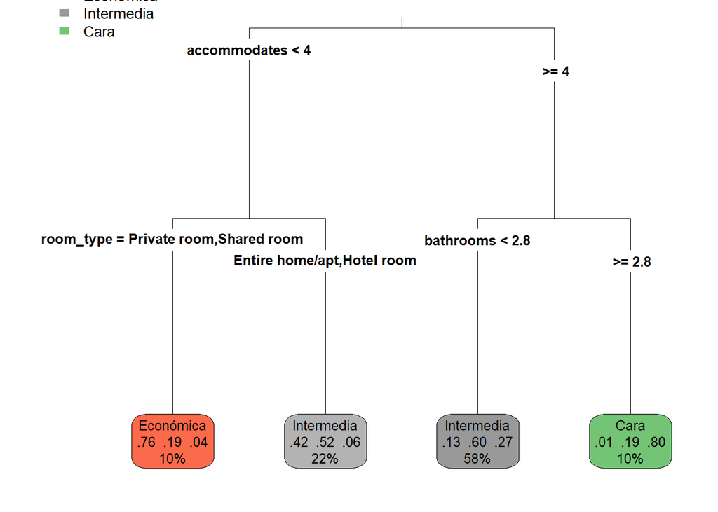

```r
rpart.plot(
  arbol_clas,
  type = 3,
  extra = 104,
  fallen.leaves = TRUE,
  cex = 0.8
)
```

```r
pred_test_clas <- predict(arbol_clas, newdata = test_clas2, type = "class")
```

```r
matriz_confusion <- table(
  Real = test_clas2$categoria_precio,
  Predicho = pred_test_clas
)

matriz_confusion
```

```
##             Predicho
## Real         Económica Intermedia Cara
##   Económica       1189       2557   20
##   Intermedia       303       6978  309
##   Cara              60       2559 1238
```

```r
accuracy <- mean(pred_test_clas == test_clas2$categoria_precio)
accuracy
```

```
## [1] 0.6182213
```

Se construyó un árbol de clasificación para predecir la variable categoria_precio, definida en tres clases: Económica, Intermedia y Cara. Dado que esta variable fue creada a partir del precio, no se incluyó price como predictor en el modelo. Para facilitar la estimación y evitar tiempos excesivos de cómputo, el árbol se ajustó usando un conjunto reducido de variables explicativas: capacidad de alojamiento, número de baños, número de habitaciones, número de camas y tipo de habitación. Posteriormente, el modelo se evaluó en el conjunto de prueba mediante una matriz de confusión y la exactitud global.